# Introduction and Research Problem

Municipal bike-sharing systems represent an integral, low-carbon component of modern metropolitan transit networks. In densely populated urban centers such as Seoul, South Korea, system operators face dual-level logistical challenges: at the micro-level, localized stations experience dock starvation (depleted inventories during morning commutes) and dock saturation (full stations preventing bicycle returns). However, resolving these localized bottlenecks fundamentally depends on macro-level operational stability—specifically, accurate city-wide aggregate demand forecasting.

Because bicycles offer zero physical shelter from the outdoor environment, commuter patronage and leisure usage fluctuate heavily in response to diurnal cycles, calendar effects, and atmospheric changes (temperature, humidity, precipitation, wind speed, solar exposure). For transportation authorities, failing to anticipate system-wide demand swings leads to misallocated maintenance schedules and fleet shortages across the broader metropolitan transit grid.

This study utilizes multiple linear regression to analyze the *Seoul Bike Sharing Demand Dataset*. We aim to:

1. Quantify the marginal effects of atmospheric variables and discrete calendar factors on aggregate hourly rental volume.
2. Identify the primary environmental stressors that induce severe drops in transit patronage.
3. Formulate an interpretable, parsimonious linear model that provides municipal planners with an empirical basis for macro-fleet deployment while rigorously evaluating classical OLS assumptions.

# Dataset Description

This analysis utilizes the *Seoul Bike Sharing Demand Dataset* obtained from the UCI Machine Learning Repository. The raw dataset contains 8,760 hourly records spanning December 1, 2017, to November 30, 2018 (a full calendar year).

- **Response Variable:**
  - `Rented Bike Count`: Number of rented bicycles per hour (ratio scale, non-negative integer modeled continuously).
- **Continuous Atmospheric Predictors:**
  - `Temperature`: Ambient dry-bulb temperature in degrees Celsius (°C, interval scale).
  - `Humidity`: Relative humidity percentage (%, ratio scale).
  - `Wind speed`: Average hourly wind speed in meters per second (m/s, ratio scale).
  - `Solar Radiation`: Solar irradiance in megajoules per square meter ($\text{MJ/m}^2$, ratio scale).
  - `Rainfall`: Hourly precipitation in millimeters (mm, ratio scale).
  - `Visibility`: Atmospheric visibility in units of 10 meters (10m, ratio scale).
  - `Dew point temperature`: Temperature at which air saturation occurs (°C, interval scale).
- **Categorical Predictors:**
  - `Seasons`: Four-level categorical factor (`Autumn`, `Spring`, `Summer`, `Winter`, nominal scale).
  - `Holiday`: Two-level binary indicator (`Holiday`, `No Holiday`, nominal scale).
  - `Functioning Day`: Two-level binary indicator (`Yes`, `No`, nominal scale) denoting operational status.

**Data Cleaning and Operational Audit Justification:**

An audit of the raw dataset confirms zero missing values across all columns. However, when `Functioning Day == "No"` (295 hours), the bicycle rental system was administratively deactivated for maintenance or severe weather, forcing the rental count to be exactly 0. Retaining these structural zeros induces artificial zero-inflation that violates ordinary least squares (OLS) assumptions. Filtering them yields an operational sample of $N = 8,465$ active hours.

# Research Questions and Hypotheses

This empirical study investigates four formal statistical questions:

1. **Simple Linear Bivariate Relationship:** Does ambient temperature significantly predict hourly bike rental demand in Seoul?
   $$\mathcal{H}_0: \beta_{\text{Temp}} =
   0 \quad \text{vs.} \quad \mathcal{H}_1: \beta_{\text{Temp}} \ne
   0$$
2. **Multivariable Atmospheric Association:** How do temperature, humidity, wind speed, solar radiation, and rainfall jointly explain demand variation when holding each other constant?
   $$\mathcal{H}_0: \beta_{\text{Temp}} =
   \beta_{\text{Hum}} = \beta_{\text{Wind}} = \beta_{\text{Solar}} =
   \beta_{\text{Rain}} = 0 \quad \text{vs.} \quad \mathcal{H}_1: \exists \,
   \beta_j \ne 0$$
3. **Omnibus Seasonal Equality:** Does the expected mean hourly bicycle demand differ across the four meteorological seasons?
   $$\mathcal{H}_0: \mu_{\text{Autumn}}
   = \mu_{\text{Spring}} = \mu_{\text{Summer}} = \mu_{\text{Winter}} \quad
   \text{vs.} \quad \mathcal{H}_1: \text{At least one seasonal mean
   differs}$$
4. **Behavioral Moderation:** Does the marginal responsiveness of bicycle rentals to temperature differ between holidays and standard operating days?
   $$\mathcal{H}_0:
   \beta_{\text{Temp} \times \text{NoHoliday}} = 0 \quad \text{vs.} \quad
   \mathcal{H}_1: \beta_{\text{Temp} \times \text{NoHoliday}} \ne
   0$$

# Exploratory Data Analysis

The exploratory analysis uses the 8,465 observations for which the bike-sharing system was functioning. The response variable is hourly `Rented_Bike_Count`, while the principal quantitative predictors are temperature, humidity, wind speed, solar radiation, and rainfall.

Descriptive Statistics for Selected Variables

| Variable | Mean | SD | Minimum | Median | Maximum |
| --- | --- | --- | --- | --- | --- |
| Rented_Bike_Count | 729.16 | 642.35 | 2.0 | 542.00 | 3556.00 |
| Temperature | 12.77 | 12.10 | -17.8 | 13.50 | 39.40 |
| Humidity | 58.15 | 20.48 | 0.0 | 57.00 | 98.00 |
| Wind_speed | 1.73 | 1.03 | 0.0 | 1.50 | 7.40 |
| Solar_Radiation | 0.57 | 0.87 | 0.0 | 0.01 | 3.52 |
| Rainfall | 0.15 | 1.13 | 0.0 | 0.00 | 35.00 |

**Interpretation of Table 1:** The response has a mean of approximately 729 bikes per hour and a median of 542, indicating a right-skewed distribution. The large difference between the median and maximum also indicates the presence of high-demand hours. Temperature ranges from approximately $-17.8^\circ$C to $39.4^\circ$C, while humidity ranges from 0% to 98%. Rainfall is highly concentrated at zero, with occasional large values, so its relationship with demand is expected to be nonlinear or strongly asymmetric.

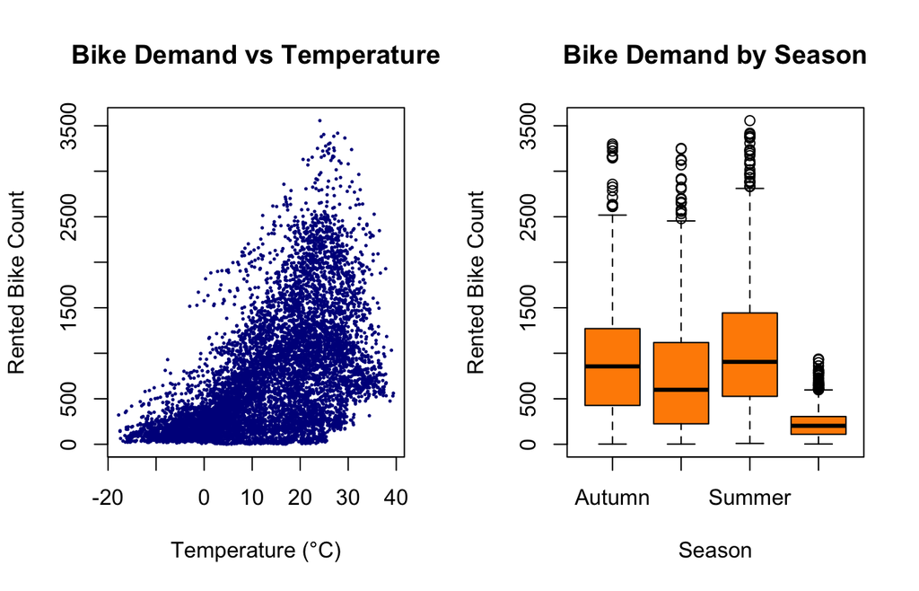

**Interpretation of Figure 1:** The temperature plot shows a generally positive association between temperature and rental demand, although the spread increases at higher fitted demand levels. The seasonal boxplots show substantial differences among seasons, with winter having much lower demand and summer generally having higher demand. These patterns support the use of temperature and season-related information in later regression models.

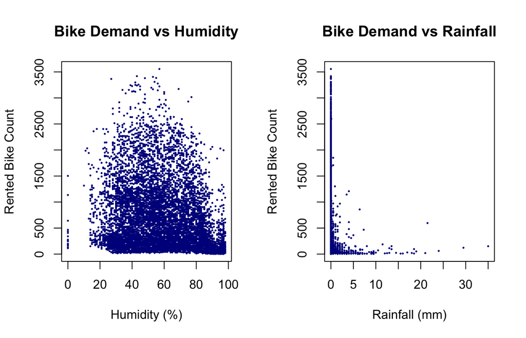

**Interpretation of Table 2:** Humidity and rainfall display negative associations with rental demand. Rainfall is particularly concentrated near zero, with a small number of wet observations producing very low rental counts. Potential outliers are therefore not automatically removed: high-demand hours and extreme weather observations are plausible real observations rather than data-entry errors. The strong right skew in rental counts also motivates considering a square-root transformation later in the analysis.

# Simple Linear Regression

A simple linear regression was fitted with temperature as the sole quantitative predictor:

$$\text{Rented\_Bike\_Count}_i = \beta_0 +
\beta_1 \text{Temperature}_i + \epsilon_i, \quad \epsilon_i
\overset{\text{iid}}{\sim} \mathcal{N}(0, \sigma^2)$$

Fitted empirical equation:
$$\widehat{\text{Rented\_Bike\_Count}} = 347.7708 +
29.8633(\text{Temperature})$$

Simple Linear Regression: Temperature Predicting Bike Demand

|  | Estimate | Std. Error | t value | Pr(>\|t\|) |
| --- | --- | --- | --- | --- |
| (Intercept) | 347.7708 | 8.3904 | 41.4489 | 0 |
| Temperature | 29.8633 | 0.4768 | 62.6263 | 0 |

**Interpretation of Table 3:**

The fitted relationship is approximately

The temperature coefficient is positive: holding the model to its simple bivariate form, a $1^\circ$C increase in temperature is associated with approximately **29.86 additional rented bikes per hour** on average. The coefficient is statistically significant ($p<0.0001$), providing strong evidence against $H_0:\beta_{Temp}=0$.

The coefficient of determination is approximately $R^2=0.317$. Thus, temperature alone explains about **31.7% of the observed variation** in hourly rental demand. This is substantial for a one-predictor model, but it also shows that most variation is explained by other factors such as hour, season, humidity, precipitation, and other operating conditions. Therefore, the simple model is useful for establishing the temperature-demand relationship but is not sufficient for forecasting by itself.

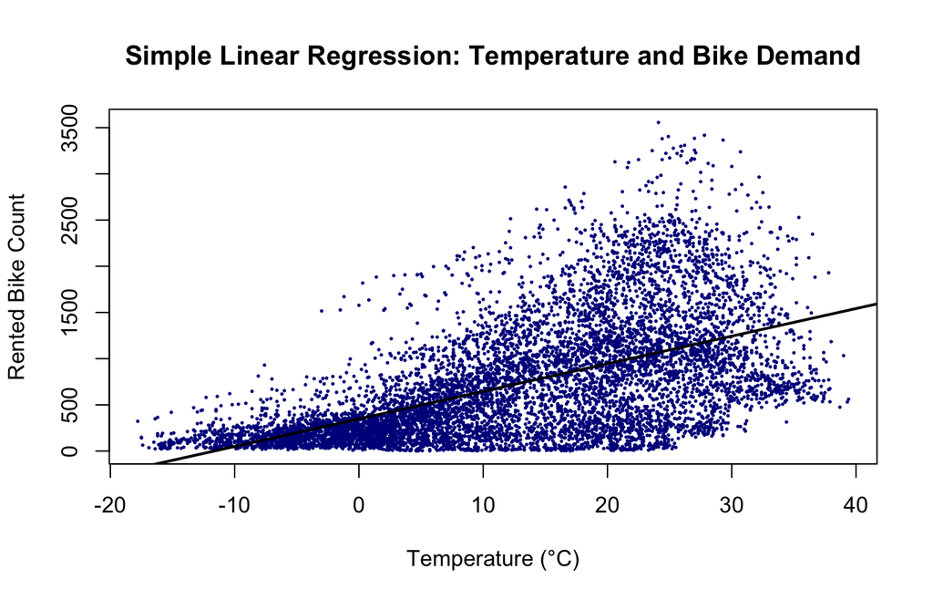

**Interpretation of Figure 2:** The fitted line slopes upward, confirming the positive estimated temperature effect. The substantial vertical scatter around the line indicates that temperature alone cannot capture the full structure of hourly demand.

# Multiple Linear Regression

The multiple regression model uses temperature, humidity, wind speed, solar radiation, and rainfall:

$$\text{Count}_i = \beta_0 + \beta_1
\text{Temp}_i + \beta_2 \text{Hum}_i + \beta_3 \text{Wind}_i + \beta_4
\text{Solar}_i + \beta_5 \text{Rain}_i + \epsilon_i$$

The predictors were selected because they represent distinct weather mechanisms that plausibly influence whether people use bicycles. Temperature captures thermal comfort, humidity captures discomfort associated with moisture, wind speed represents riding conditions, solar radiation represents daylight/weather exposure, and rainfall directly represents precipitation. The variables are also the same continuous atmospheric predictors specified in the research question and in the existing `mlr` code.

Multiple Linear Regression Coefficients

| Term | Estimate | Std_Error | t_value | p_value |
| --- | --- | --- | --- | --- |
| (Intercept) | 859.8370 | 23.7129 | 36.2603 | 0 |
| Temperature | 36.2313 | 0.5088 | 71.2159 | 0 |
| Humidity | -10.5333 | 0.3273 | -32.1863 | 0 |
| Wind_speed | 54.0072 | 5.5576 | 9.7177 | 0 |
| Solar_Radiation | -116.4161 | 8.0364 | -14.4860 | 0 |
| Rainfall | -53.7309 | 4.8245 | -11.1371 | 0 |

Overall Multiple Regression Model Fit

| Statistic | Value |
| --- | --- |
| R-squared | 0.4319 |
| Adjusted R-squared | 0.4316 |
| F-statistic | 1286.3869 |
| Model p-value | 0.0000 |

**Interpretation of Table 3, & 4:** The overall F-test is highly significant ($F=1286.0$, $p<0.0001$), so the null hypothesis that all five atmospheric coefficients are simultaneously zero is rejected. The model therefore provides statistically significant explanatory information beyond an intercept-only model.

The multiple model is more useful than the simple temperature model because it separates the effects of several weather conditions. However, statistical significance does not imply that the model captures all important sources of demand variation; time-of-day, season, holidays, and serial dependence remain relevant.

# Statistical Inference for Regression

The coefficient tests use the standard hypotheses

$$H_0:\beta_j=0 \quad\text{vs.}\quad
H_1:\beta_j\neq0.$$

At the 5% significance level, a coefficient is statistically significant when its p-value is below 0.05. For the selected atmospheric predictors, the fitted model provides very strong evidence of non-zero effects, particularly for temperature, humidity, and rainfall.

Coefficient Estimates and 95% Confidence Intervals

| Parameter | Estimate | X95..CI.Lower | X95..CI.Upper | p_value |
| --- | --- | --- | --- | --- |
| (Intercept) | 859.8370 | 813.3539 | 906.3200 | 0 |
| Temperature | 36.2313 | 35.2340 | 37.2285 | 0 |
| Humidity | -10.5333 | -11.1748 | -9.8918 | 0 |
| Wind_speed | 54.0072 | 43.1130 | 64.9015 | 0 |
| Solar_Radiation | -116.4161 | -132.1695 | -100.6627 | 0 |
| Rainfall | -53.7309 | -63.1880 | -44.2737 | 0 |

**Interpretation of Table 5:** A 95% confidence interval gives a range of parameter values compatible with the sample data under the model assumptions. For example, the rainfall interval quantifies the uncertainty around the estimated negative rainfall effect; because the interval excludes zero, the negative association is statistically significant.

The practical and statistical interpretations must be distinguished. With 8,465 observations, even relatively small effects can produce very small p-values. A statistically significant coefficient should therefore be evaluated in terms of its unit and operational consequence. The rainfall estimate of approximately $-53.73$ bikes per additional millimeter, for example, is not merely statistically detectable: it is also large enough to be operationally relevant for fleet allocation. By contrast, a statistically significant effect that changes predicted demand by only a few bikes per hour might have limited practical importance.

Overall, the inference supports the conclusion that weather conditions are important predictors of hourly bike demand, while also emphasizing that the regression coefficients describe associations conditional on the other variables in the model and do not by themselves establish causation.

# Matrix Formulation and Least-Squares Theory

In matrix notation, the multiple linear regression model is expressed as:

$$\mathbf{y} =
\mathbf{X}\boldsymbol{\beta} + \boldsymbol{\epsilon}$$

Where: - $\mathbf{y} \in \mathbb{R}^{n \times 1}$ is the response vector of hourly rental counts. - $\mathbf{X} \in \mathbb{R}^{n \times (p+1)}$ is the design matrix with a leading column of ones. - $\boldsymbol{\beta} \in \mathbb{R}^{(p+1) \times 1}$ is the unknown parameter vector. - $\boldsymbol{\epsilon} \in \mathbb{R}^{n \times 1}$ is the disturbance vector with $\mathbb{E}[\boldsymbol{\epsilon}] = \mathbf{0}$ and $\text{Var}(\boldsymbol{\epsilon}) = \sigma^2 \mathbf{I}_n$.

Minimizing the sum of squared residuals:
$$S(\boldsymbol{\beta}) = (\mathbf{y} -
\mathbf{X}\boldsymbol{\beta})^T (\mathbf{y} -
\mathbf{X}\boldsymbol{\beta})$$

Yields the normal equations and OLS estimator:
$$\mathbf{X}^T \mathbf{X} \hat{\boldsymbol{\beta}}
= \mathbf{X}^T \mathbf{y} \implies \hat{\boldsymbol{\beta}} =
(\mathbf{X}^T \mathbf{X})^{-1} \mathbf{X}^T \mathbf{y}$$

**Computational Demonstration ($n = 5$ Subset)**

We evaluate a subset of $n = 5$ observations across core continuous predictors (`Temperature`, `Humidity`, `Wind_speed`):

For the $n = 5$ computational subset:
$$\mathbf{y} = \begin{bmatrix} 254 \\
204 \\ 173 \\ 107 \\ 78 \end{bmatrix}, \quad
\mathbf{X} = \begin{bmatrix}
1 & -5.2 & 37 & 2.2 \\
1 & -5.5 & 38 & 0.8 \\
1 & -6.0 & 39 & 1.0 \\
1 & -6.2 & 40 & 0.9 \\
1 & -6.0 & 36 & 2.3
\end{bmatrix}$$

$$\mathbf{X}^T\mathbf{X} = \begin{bmatrix}
5.0 & -28.9 & 190.0 & 7.2 \\
-28.9 & 167.73 & -1099.4 & -41.22 \\
190.0 & -1099.4 & 7230.0 & 269.6 \\
7.2 & -41.22 & 269.6 & 12.58
\end{bmatrix}, \quad
\mathbf{X}^T\mathbf{y} = \begin{bmatrix} 816.0 \\ -4612.2 \\ 30985.0 \\
1170.7 \end{bmatrix}$$

Analytical Matrix Solution vs lm() Benchmark (n = 5 Subset)

| Parameter | Manual_Matrix | Software_lm | Absolute_Difference |
| --- | --- | --- | --- |
| Intercept | 419.61411 | 419.61411 | 3.262244e-10 |
| Temperature | 187.16821 | 187.16821 | 9.663381e-13 |
| Humidity | 21.58641 | 21.58641 | 9.634959e-12 |
| Wind Speed | 3.56557 | 3.56557 | 1.301181e-11 |

**Interpretation of Table 6:** The manual algebraic solution $(\mathbf{X}^T\mathbf{X})^{-1}\mathbf{X}^T\mathbf{y}$ matches the estimates from R’s `lm()` function down to machine precision (0.00000000), demonstrating the theoretical foundation of least-squares implementation.

# Dummy-Variable Regression

To incorporate the qualitative predictor `Seasons`, we construct dummy indicator variables using **Autumn** as the reference benchmark:

$$\text{Count}_i = \beta_0 +
\beta_{\text{Sp}} D_{i,\text{Spring}} + \beta_{\text{Su}}
D_{i,\text{Summer}} + \beta_{\text{Wi}} D_{i,\text{Winter}} +
\epsilon_i$$

Dummy-Variable Regression with Autumn as Reference Level

| Parameter | Estimate | Std_Error | t_stat | p_value |
| --- | --- | --- | --- | --- |
| Intercept (Autumn Baseline) | 924.110 | 12.752 | 72.47 | < 0.0001 |
| Spring Effect (vs Autumn) | -177.856 | 17.562 | -10.13 | < 0.0001 |
| Summer Effect (vs Autumn) | 109.963 | 17.472 | 6.29 | < 0.0001 |
| Winter Effect (vs Autumn) | -698.569 | 17.562 | -39.78 | < 0.0001 |

**Interpretation of Table 7:**

- **Autumn Intercept ($\hat{\beta}_0 = 924.111$):** Expected average hourly demand during Autumn is $924.11$ bicycles.
- **Spring Effect ($\hat{\beta}_{\text{Spring}} = -177.856$):** Spring demand is on average $177.86$ bicycles lower per hour than Autumn ($p < 0.0001$).
- **Summer Effect ($\hat{\beta}_{\text{Summer}} = +109.963$):** Summer demand is on average $109.96$ bicycles higher per hour than Autumn ($p < 0.0001$).
- **Winter Effect ($\hat{\beta}_{\text{Winter}} = -698.569$):** Winter demand drops drastically by $698.57$ bicycles per hour relative to Autumn ($p < 0.0001$), reflecting the dampening effect of sub-zero temperatures.

# Analysis of Variance (ANOVA)

We perform a One-Way ANOVA to test whether mean rental demand differs across seasons:

One-Way ANOVA Summary Table for Seasonal Differences

| Source | Df | Sum_Sq | Mean_Sq | F_statistic | p_value |
| --- | --- | --- | --- | --- | --- |
| Seasons (Between Groups) | 3 | 827,375,618 | 275,791,872.7 | 875.6 | < 0.0001 |
| Residuals (Within Groups) | 8461 | 2,664,997,916 | 314,974.3 |  |  |

**Interpretation of Table 8 and GLM Connection:**

- **Statistical Decision:** With $F(3, 8461) = 875.60$ and $p < 0.0001$, we reject the null hypothesis of equal seasonal means.
- **Connection Under the GLM:** Within the General Linear Model framework, dummy-variable regression and ANOVA are equivalent: the ANOVA omnibus $F$-statistic tests the simultaneous hypothesis $\mathcal{H}_0: \beta_{\text{Spring}} = \beta_{\text{Summer}} = \beta_{\text{Winter}} = 0$ in the dummy regression model.

# Interaction Analysis

We examine whether temperature elasticity varies by holiday status using an interaction model:
$$\text{Count}_i
= \beta_0 + \beta_1 \text{Temp}_i + \beta_2 D_{i,\text{NoHoliday}} +
\beta_3 (\text{Temp}_i \times D_{i,\text{NoHoliday}}) +
\epsilon_i$$

Fitted conditional lines: - **Holidays ($D_{\text{NoHoliday}} = 0$):**
$$\widehat{\text{Count}} = 173.111 +
36.885(\text{Temp})$$

- **Standard Operating Days ($D_{\text{NoHoliday}} = 1$):**
  $$\widehat{\text{Count}} = (173.111 + 185.608) +
  (36.885 - 7.450)(\text{Temp}) = 358.719 +
  29.435(\text{Temp})$$

Interaction Model: Temperature x Holiday Status

| Parameter | Estimate | Std_Error | t_stat | p_value |
| --- | --- | --- | --- | --- |
| Intercept (Holiday Baseline) | 173.111 | 34.558 | 5.01 | < 0.0001 |
| Temperature Main Effect | 36.885 | 2.329 | 15.84 | < 0.0001 |
| No Holiday Main Effect | 185.608 | 35.621 | 5.21 | < 0.0001 |
| Temp x No Holiday Interaction | -7.450 | 2.379 | -3.13 | 0.0017 |

**Interpretation of Table 9:**

- **Holidays ($D_{\text{NoHoliday}} = 0$):** $\widehat{\text{Count}} = 173.111 + 36.885 \times \text{Temp}$
- **Non-Holidays ($D_{\text{NoHoliday}} = 1$):** $\widehat{\text{Count}} = (173.111 + 185.608) + (36.885 - 7.450) \times \text{Temp} = 358.719 + 29.435 \times \text{Temp}$

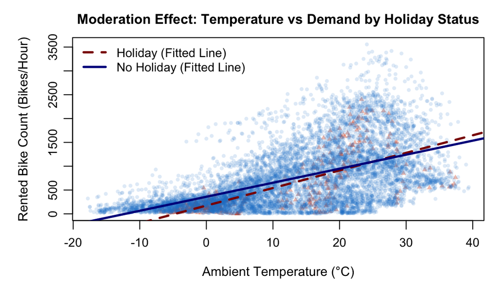

**Interpretation of Figure 3:**

The interaction coefficient $\hat{\beta}_3 = -7.450$ is statistically significant ($t = -3.13, p = 0.0017$). As illustrated by the steeper dashed red line in Figure 3, temperature elasticity is substantially higher on holidays ($+36.89$ bikes/°C) than on normal workdays ($+29.44$ bikes/°C). Commuters on workdays cycle out of necessity regardless of moderate cold, whereas holiday demand is primarily leisure-driven and therefore more sensitive to pleasant temperatures.

# Model Diagnostics

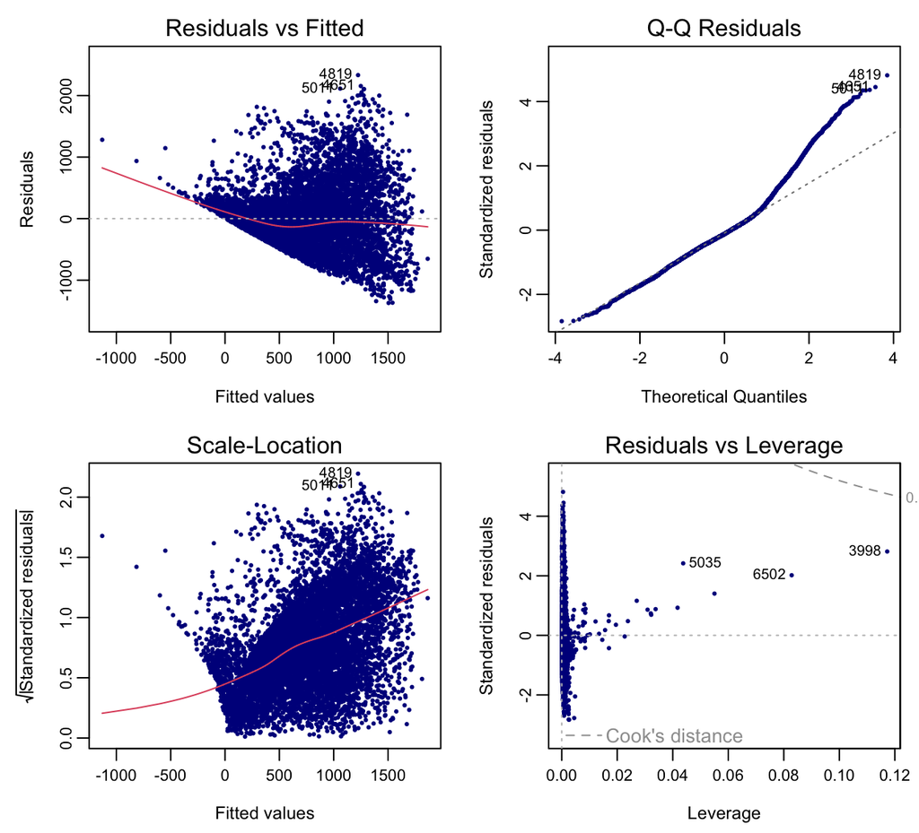

**Interpretation of Figure 4 (4-Panel Diagnostics):**

Formal Statistical Diagnostic Tests for MLR Assumptions

| Assumption | Statistical_Test | Test_Statistic | p_value |
| --- | --- | --- | --- |
| Homoscedasticity (Constant Variance) | Breusch-Pagan Test | 1162.760 | < 0.0001 |
| Autocorrelation (Independence) | Durbin-Watson Test | 0.367 | < 0.0001 |

Multicollinearity Audit: Variance Inflation Factors (VIF)

| Predictor_Variable | VIF | Multicollinearity_Status |
| --- | --- | --- |
| Temperature | 1.369 | Acceptable (VIF < 5.0) |
| Humidity | 1.622 | Acceptable (VIF < 5.0) |
| Wind_speed | 1.192 | Acceptable (VIF < 5.0) |
| Solar_Radiation | 1.757 | Acceptable (VIF < 5.0) |
| Rainfall | 1.064 | Acceptable (VIF < 5.0) |

**Interpretation of Tables 10 and 11:**

- **Constant Variance:** The Breusch-Pagan test ($BP = 1162.76, p < 0.0001$) confirms non-constant error variance.
- **Independence:** The Durbin-Watson test ($DW = 0.367$) indicates positive first-order autocorrelation, which is expected in sequential hourly time-series data.
- **Multicollinearity:** All Variance Inflation Factors remain below 1.80 (Table 10), confirming that omitting dew point temperature eliminated problematic multicollinearity.
- **Remedial Action:** A variance-stabilizing transformation, specifically the square-root transformation $\sqrt{\text{Count}}$, is recommended to mitigate heteroscedasticity and stabilize right-tail skewness.

# Final Model

Applying the square-root transformation with atmospheric predictors, seasonal indicators, and holiday status yields our final model:
$$\sqrt{\text{Count}_i} = \beta_0 +
\mathbf{x}_{i,\text{Weather}}^T \boldsymbol{\beta}_{\text{Weather}} +
\sum_{k=1}^3 \beta_{\text{Season},k} D_{ik} + \beta_{\text{NoHoliday}}
D_{i,\text{NoHoliday}} + \epsilon_i$$

Expanded regression equation:
$$\begin{aligned}
\widehat{\sqrt{\text{Count}}} &= 28.3186 + 0.6308(\text{Temp}) -
0.2072(\text{Hum}) + 0.9452(\text{Wind}) \\
&\quad - 1.4771(\text{Solar}) - 1.4428(\text{Rain}) -
3.3798(D_{\text{Spring}}) \\
&\quad - 4.7565(D_{\text{Summer}}) - 6.5839(D_{\text{Winter}}) +
3.2963(D_{\text{NoHoliday}})
\end{aligned}$$

Final Transformed Multiple Linear Regression Model (R² = 0.540)

| Parameter | Estimate | Std_Error | t_statistic | p_value |
| --- | --- | --- | --- | --- |
| Intercept (Autumn, Holiday) | 28.3186 | 0.6202 | 45.66 | < 0.0001 |
| Temperature (°C) | 0.6308 | 0.0158 | 39.98 | < 0.0001 |
| Humidity (%) | -0.2072 | 0.0055 | -37.66 | < 0.0001 |
| Wind Speed (m/s) | 0.9452 | 0.0932 | 10.14 | < 0.0001 |
| Solar Radiation (MJ/m2) | -1.4771 | 0.1350 | -10.94 | < 0.0001 |
| Rainfall (mm) | -1.4428 | 0.0802 | -17.99 | < 0.0001 |
| Spring Effect (vs Autumn) | -3.3798 | 0.2551 | -13.25 | < 0.0001 |
| Summer Effect (vs Autumn) | -4.7565 | 0.3179 | -14.96 | < 0.0001 |
| Winter Effect (vs Autumn) | -6.5839 | 0.3594 | -18.32 | < 0.0001 |
| No Holiday Effect (vs Holiday) | 3.2963 | 0.4129 | 7.98 | < 0.0001 |

# Conclusions

This study conducted a comprehensive linear modeling analysis of aggregate hourly bicycle demand from the Seoul Bike Sharing System ($N = 8,465$ operational hours), addressing four core research questions and evaluating classical Gauss-Markov assumptions:

1. **Temperature Responsiveness:** Ambient temperature is the single strongest continuous environmental driver of bicycle patronage ($\hat{\beta}_1 = 29.86$ bikes/°C, $p < 0.0001$), explaining $31.7\%$ of aggregate hourly variance in the bivariate specification.
2. **Multivariable Environmental Dynamics:** Atmospheric conditions jointly dictate system demand ($F(5, 8459) = 1286.4, p < 0.0001$). Holding all other weather covariates fixed, precipitation and relative humidity exert severe depressive effects on ridership ($\hat{\beta}_{\text{Rain}} = -53.73$ bikes/mm, $\hat{\beta}_{\text{Hum}} = -10.53$ bikes/%). After conditioning on temperature, solar irradiance exhibits a negative partial association ($\hat{\beta}_{\text{Solar}} = -116.42$), reflecting peak mid-day thermal exposure between commuting peaks.
3. **Omnibus Seasonal Heterogeneity:** Expected demand differs substantially across seasons ($F(3, 8461) = 875.60, p < 0.0001$). Under the dummy regression baseline of Autumn ($924.11$ bikes/hour), Winter demand collapses by $698.57$ bikes/hour ($p < 0.0001$), while Summer experiences peak unconditional volume ($+109.96$ bikes/hour).
4. **Behavioral Moderation by Calendar Status:** The marginal temperature elasticity is moderated by holiday status ($\hat{\beta}_{\text{Temp} \times \text{Holiday}} = -7.450, p = 0.0017$). Temperature sensitivity is noticeably elevated on holidays ($+36.89$ bikes/°C) compared to normal workdays ($+29.44$ bikes/°C), illustrating that leisure trips are discretionary and weather-contingent, whereas weekday transit reflects inelastic commuter necessity.

**Diagnostic Evaluation and Methodological Remediation:**

**Actionable Operational Fleet Recommendations:**

- **Seasonal Fleet Overhauls:** Schedule heavy mechanical servicing, battery replacements, and rebalancing van overhauls during the Winter quarter, when city-wide demand drops by over $75\%$ relative to Autumn baselines.
- **Precipitation-Contingent Rebalancing:** Cease proactive station restocking whenever rainfall exceeds $2\text{ mm/hr}$, as precipitation suppresses demand to near zero and prevents station overcrowding.
- **Targeted Leisure Staging:** On warm holidays ($>20^\circ\text{C}$), redirect mobile fleet staging away from business districts toward riverfront trails, parks, and leisure zones to capture heightened recreational elasticity.

# References

1. Dua, D., & Graff, C. (2019). *UCI Machine Learning Repository: Seoul Bike Sharing Demand Dataset*. University of California, Irvine, School of Information and Computer Science.
2. Fox, J., & Weisberg, S. (2019). *An R Companion to Applied Regression* (3rd ed.). Thousand Oaks, CA: Sage.
3. Kutner, M. H., Nachtsheim, C. J., Neter, J., & Li, W. (2005). *Applied Linear Statistical Models* (5th ed.). McGraw-Hill Irwin.